## Multivariate Analysis

We have many variables with corresponding data, so we want to make sense of them.

### 1. Introduction - Background

- Matrix Algebra
- Summary Statistics
  - Matrix Algebra
  - Multivariate Normal Distribution

#### 1.1 Introduction to Matrix Algebra

What is Matrix?

- A way to group number or symbols together, where you have rows and columns
- A matrix is a rectangular array of elements arranged in rows and columns

The dimension of a matrix is giving by:

- Rows
- Columns
- Rows X Columns $r x c$

Here we have a 3x2 Matrix

```r
matrix(data = c(1, 2, 3, 4, 5, 6),
       nrow = 3,
       ncol = 2)
```

```
##      [,1] [,2]
## [1,]    1    4
## [2,]    2    5
## [3,]    3    6
```

Rather than using numbers, we can represent parts of a matrix (and the matrix itself) by symbols.

Example:

$$A = \begin{bmatrix} a_{11} \ a_{12} \
a_{13} \\ a_{21} \ a_{22} \ a_{23} \end{bmatrix}$$

Where $a_{ij}$ is the row $i$ and column $j$ element of $A$. $a_{11}$ is often called $(1,1)$ element of $A$, $a_{12}$ is the $(1,2)$ element of $A.

When writing in hand we cannot bold the letter $A$ so we use the underlined $\underline{A}$

Square matrix is $r x c$ where $r = c$

**Vector** - A $r x 1$ is a *column vector*

**Vector** - A $1 x r$ is a *row vector*

Both being a special case matrix.

```r
matrix(data = c(1, 2, 3),
       ncol = 1,
       nrow = 3)
```

```
##      [,1]
## [1,]    1
## [2,]    2
## [3,]    3
```

**Transpose** - Is when we interchange the rows and columns of a matrix or vector

Example:

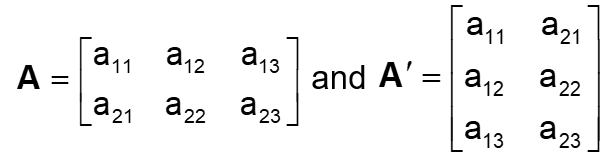

$$A = \begin{bmatrix} a_{11} \ a_{12} \
a_{13} \\ a_{21} \ a_{22} \ a_{23} \end{bmatrix}$$

$$A' = \begin{bmatrix} a_{11} \ a_{21}
\\ a_{12} \ a_{22} \\ a_{13} \ a_{23} \end{bmatrix}$$

```r
matrix(data = c(1, 2, 3, 4, 5, 6),
       nrow = 2,
       ncol = 3)
```

```
##      [,1] [,2] [,3]
## [1,]    1    3    5
## [2,]    2    4    6
```

```r
matrix(data = c(1, 2, 3, 4, 5, 6),
       nrow = 3,
       ncol = 2)
```

```
##      [,1] [,2]
## [1,]    1    4
## [2,]    2    5
## [3,]    3    6
```

$A$ is 2x3 and $A'$ is a 3x2. The $'$ symbol indicates a transpose, and it is said as the word *prime*. Thus, the transpose of $A$ is *A prime*.

##### 1.1.1 Introduction to Matrix Algebra - Matrix addition and subtraction

Adding or subtraction the corresponding elements of matrices *with the same dimension*.

Example

```r
MA <- matrix(data = c(1, 2, 3, 5, 6, 7),
             nrow = 2,
             ncol = 3,
             byrow = TRUE)

MB <- matrix(data = c(-1, 10, -1, 5, 5, 8),
             nrow = 2,
             ncol = 3,
             byrow = TRUE)
MA
```

```
##      [,1] [,2] [,3]
## [1,]    1    2    3
## [2,]    5    6    7
```

```r
MB
```

```
##      [,1] [,2] [,3]
## [1,]   -1   10   -1
## [2,]    5    5    8
```

Then $A + B$ is:

```r
MA + MB
```

```
##      [,1] [,2] [,3]
## [1,]    0   12    2
## [2,]   10   11   15
```

and $A - B$ is:

```r
MA - MB
```

```
##      [,1] [,2] [,3]
## [1,]    2   -8    4
## [2,]    0    1   -1
```

`byrow` by default is set to `FALSE`. Thus, the number would be entered into the matrix by columns. Example

```r
MX <- matrix(data = c(1, 2, 3, 5, 6, 7),
             nrow = 2,
             ncol = 3,
             byrow = FALSE)
MX
```

```
##      [,1] [,2] [,3]
## [1,]    1    3    6
## [2,]    2    5    7
```

```r
class(MX)
```

```
## [1] "matrix" "array"
```

A transpose of a matri can be done using the `t()` function.

```r
t(MX)
```

```
##      [,1] [,2]
## [1,]    1    2
## [2,]    3    5
## [3,]    6    7
```